# 2020 Black Population-WEB DuBois Visualization

Christie Williams

4/10/2022

## Purpose

This work utilizes 2020 US Voting data to analyze the black voting population by state and applies techniques of W.E.B. Dubois to visualize the top 15 most popluated by blacks in the US.

## Add Libraries

Packages were previously installed. Calling all libraries used in this work.

```r
library(ggplot2)
library(dplyr)
library(tidyverse)
library(openxlsx)
```

## Step 1: Import Data

Data is imported from US Census Bureau and saved to “testFrame” dataframe.

## Step 2: Clean Data

### Add State Names

Currently, state names are listed once for state totals and absent from the breakdown of sex, race, and Hispanic-Origin. The below code adds state names to each of the demographics.

```r
testFrame[6:15, 1] <- "US"
testFrame[17:26, 1] <- "ALABAMA"
testFrame[28:37, 1] <- "ALASKA"
testFrame[39:48, 1] <- "ARIZONA"
testFrame[50:59, 1] <- "ARKANSAS"
testFrame[61:70, 1] <- "CALIFORNIA"
testFrame[72:81, 1] <- "COLORADO"
testFrame[83:92, 1] <- "CONNECTICUT"
testFrame[94:103, 1] <- "DELAWARE"
testFrame[105:114, 1] <- "DISTRICT OF COLUMBIA"
testFrame[116:125, 1] <- "FLORIDA"
testFrame[127:136, 1] <- "GEORGIA"
testFrame[138:147, 1] <- "HAWAII"
testFrame[149:158, 1] <- "IDAHO"
testFrame[160:169, 1] <- "ILLINOIS"
testFrame[171:180, 1] <- "INDIANA"
testFrame[182:191, 1] <- "IOWA"
testFrame[193:202, 1] <- "KANSAS"
testFrame[204:213, 1] <- "KENTUCKY"
testFrame[215:224, 1] <- "LOUISIANA"
testFrame[226:235, 1] <- "MAINE"
testFrame[237:246, 1] <- "MARYLAND"
testFrame[248:257, 1] <- "MASSACHUSETTS"
testFrame[259:268, 1] <- "MICHIGAN"
testFrame[270:279, 1] <- "MINNESOTA"
testFrame[281:290, 1] <- "MISSISSIPPI"
testFrame[292:301, 1] <- "MISSOURI"
testFrame[303:312, 1] <- "MONTANA"
testFrame[314:323, 1] <- "NEBRASKA"
testFrame[325:334, 1] <- "NEVADA"
testFrame[336:345, 1] <- "NEW HAMPSHIRE"
testFrame[347:356, 1] <- "NEW JERSEY"
testFrame[358:367, 1] <- "NEW MEXICO"
testFrame[369:378, 1] <- "NEW YORK"
testFrame[380:389, 1] <- "NORTH CAROLINA"
testFrame[391:400, 1] <- "NORTH DAKOTA"
testFrame[402:411, 1] <- "OHIO"
testFrame[413:422, 1] <- "OKLAHOMA"
testFrame[424:433, 1] <- "OREGON"
testFrame[435:444, 1] <- "PENNSYLVANIA"
testFrame[446:455, 1] <- "RHODE ISLAND"
testFrame[457:466, 1] <- "SOUTH CAROLINA"
testFrame[468:477, 1] <- "SOUTH DAKOTA"
testFrame[479:488, 1] <- "TENNESSEE"
testFrame[490:499, 1] <- "TEXAS"
testFrame[501:510, 1] <- "UTAH"
testFrame[512:521, 1] <- "VERMONT"
testFrame[523:532, 1] <- "VIRGINIA"
testFrame[534:543, 1] <- "WASHINGTON"
testFrame[545:554, 1] <- "WEST VIRGINIA"
testFrame[556:565, 1] <- "WISCONSIN"
testFrame[567:576, 1] <- "WYOMING"
```

### Create New Dataframe

Unutilized comments and headers are removed. Data utilized in visualization is extracted into a new dataframe and column headers are added.

```r
testFrame <- testFrame[-577:-583, ]
testFrame <- testFrame[-1:-4, ]
testFrame <- testFrame[ , c(1:3, 5, 10)]
colnames(testFrame) <- c("State", "SexRaceHispanic", "Population", "Registered",
                         "Voted")
```

### Convert Data Types

Conversion of data types for data manipulation. State names, totals, and demographics are changed to factors. Numbers such as Population, Registered, and Voted are changed from character to numeric. Row names (numbers) are reset.

```r
testFrame$State <- as.factor(testFrame$State)
testFrame$SexRaceHispanic <- as.factor(testFrame$SexRaceHispanic)
testFrame$Population <- as.numeric(testFrame$Population)
testFrame$Registered <- as.numeric(testFrame$Registered)
testFrame$Voted <- as.numeric(testFrame$Voted)
rownames(testFrame) = NULL
```

## Step 3: Data Manipulation

### Filter dataframe

Dataframe is filtered for “Black alone” and state names changed to uppercase, and total US black population removed. to create W.E.B. Dubois’s visualization (Plate 3).

```r
BlackPopulation <- testFrame %>%
  filter(SexRaceHispanic == "Black alone") %>%
  mutate(State = toupper(State))

BlackPopulation <- BlackPopulation[-1, ]
```

## Step 4: Visualization

### Create Graph

dplyr and ggplot2 are utilized to plot the top 15 US states with the highest black populations.

### Adapted from Ella Hollowood [link](https://rpubs.com/ejhollowood/du-bois)

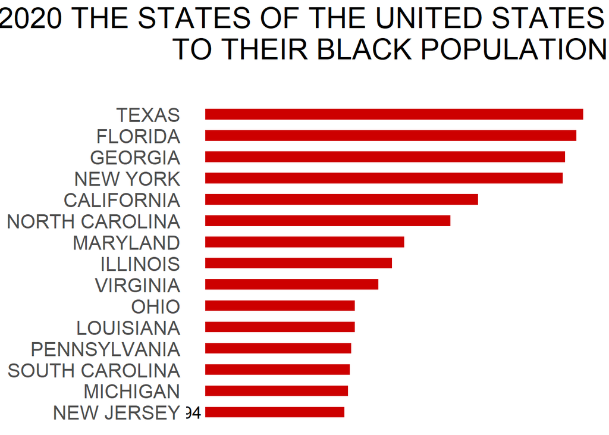

```r
top_n(BlackPopulation, n = 15, Population) %>%
  ggplot(., aes(x = reorder(State, Population), y = Population)) +
  geom_bar(
    stat = "identity",
    width = 0.5,
    fill = "red3") +
  coord_flip() +
  geom_text(data = subset(BlackPopulation, Population >= 2700),
            aes(y = Population, ymax = Population, label = Population),
            hjust = 13, size = 5) +
  geom_text(data = subset(BlackPopulation, Population == 994),
            aes(y = Population, ymax = Population, label = Population),
            hjust = 6 , size = 5) +
  theme(text = element_text(),
        panel.background = element_blank(),
        axis.title = element_blank(),
        axis.text.x = element_blank(),
        axis.text.y = element_text(size = 16),
        axis.ticks = element_blank(),
        panel.grid = element_blank(),
        plot.title = element_text(size = 24, hjust = 0.5, margin = margin(0,0,30,0))) +
  labs(title = "2020 THE STATES OF THE UNITED STATES ACCORDING\nTO THEIR BLACK POPULATION.")
```